# Diplomado en Análisis de datos con R para la acuicultura

20/4/2021

**PLAN DE CLASE**

**1).** **Introducción**

- **Preguntas al curso.**
- **Estudio de caso.**
- **Investigación reproducible.**
- **Software para el análisis de datos.**

**2).** **Práctica con R y Rstudio cloud**

- **Iniciar un proyecto de análisis de datos con R.**
- **Escribir un código de programación o script.**
- **Familiarizarse con manipulación de objetos y datos.**

**Introducción**

*Clase 2 – Programación con R*

**PREGUNTAS AL CURSO**

**1).** **¿ Por qué deseas hacer análisis de datos con R?**

**2).** **¿ Qué problemas has tenido cuando quieres rehacer un análisis de datos a partir de un set de datos antiguo o en el que no has trabajado por mucho tiempo?**

**ESTUDIO DE CASO: Bloom de algas marzo 2016**

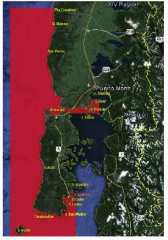

*CONSECUENCIAS ACUICULTURA*

**Acuicultura**

45 centros de cultivo

14 empresas

**Mortalidad**

+25 millones de peces

40 mil toneladas

**Vertimiento de mortalidad al mar**

5.000 toneladas

**ESTUDIO DE CASO:Reporte Greanpeace**

**Reporte Crisis Social Ambiental en Chiloé**

**GREANPEACE**

**Resumen Ejecutivo Septiembre 2016**

La principal conclusión de esta investigación es que si bien el **bloom de algas** estaba presente en la zona con anterioridad al vertimiento, **el salmón vertido actuó como un “fertilizante” de éste aumentando su magnitud, intensidad y alcance.**

**TRABAJO EN GRUPO**

**¿Quién fue el analista?**

**¿Qué datos están disponibles?**

**¿Qué software se utilizó para los análisis?**

**¿Qué test estadístico se utilizó y cuál fue su significancia?**

**¿Podría usted llegar a la misma conclusión del reporte con la información disponible?**

**INVESTIGACIÓN REPRODUCIBLE**

**Investigación reproducible** implica que desde los mismos datos y códigos se generarán los mismos resultados.

[figure not shown]

**ALGUNOS CRITERIOS DE REPRODUCIBILIDAD**

- **Los datos originales están disponibles en la nube.**
- Los datos están almacenados en formato abierto (texto) .
- **Todo el análisis y manejo de datos se hace mediante código.**
- El código genera las tablas y figuras finales.
- **Los datos brutos están separados de los datos derivados.**
- Existe un *‘script’* maestro que ejecuta todos los pasos del análisis ordenadamente.
- **Existe un documento README que explica los objetivos y organización del proyecto.**
- Tanto el reporte, como los datos y código son públicos.

**BENEFICIOS DE LA CIENCIA REPRODUCIBLE PARA EL ANALISTA DE DATOS**

- **Permite la ejecución de tareas de análisis repetitivo sin esfuerzo.**
- Muy fácil corregir y regenerar resultados, tablas y figuras.
- **Reducción drástica del riesgo de errores.**
- Facilitan la colaboración.
- **Mayor facilidad para escribir reportes.**
- Facilita el proceso de revisión.
- **Ahorro de tiempo y esfuerzo al reutilizar código en otros proyectos.**

**¿QUÉ ES R?**

**1).** **R** es un lenguaje y entorno de programación de código abierto o libre creado por Ross Ihaka y Robert Gentleman en 1993 (University of Auckland) para realizar análisis estadísticos y gráficos.

**2).** Los usuarios de R tienen la libertad de ejecutar, copiar, distribuir, estudiar, modificar y mejorar el *software*.

**3).** Utilizar **R** supone un ahorro económico para los estudiantes, las instituciones educativas o incluso las empresas que decidan usarlo.

**¿POR QUÉ USAR “R” EN CIENCIA REPRODUCIBLE?**

- Aprender a usar **R** te da *independencia digital*, te permite *cooperar con otros* y *beneficiarte de la ayuda de otro.*
- Actualmente existen cerca de **17.000 librerías** o aplicaciones disponibles de forma gratuita para trabajar con R en ámbitos tan diferentes como las ciencias sociales, la economía, la astronomía, la ingeniería y la acuicultura.
- **R** permite entonces difundir el conocimiento a toda la sociedad y no solo a los que pueden pagar por ella.

**¿QUÉ ES R STUDIO?**

- **Rstudio** es el más popular entorno de desarrollo integrado (integrated development environment, IDE) para trabajar con **R**.
- **Rstudio** es un *software* libre y de código abierto creado por **Joseph J. Allaire en 2009** para la ciencia de datos, la investigación científica y la comunicación técnica.
- Actualmente es mantenido por la Corporación de Beneficio Público **Rstudio PCB**, la que ha creado otros software como Rmarkdown.

**R ES UN LENGUAJE ORIENTADO A OBJETOS**

[figure not shown]

- Trabajan ad honoren.
- Apagan incendios.
- Puede usar diferentes equipos.
- Reciben instrucciones sobre como apagar un incendio.
- No pueden detener a ladrones.
- Almacenan texto o números.
- Primera fila contiene el nombre de variables.
- Puedo unir con otro **data.frame**.
- Puedo aplicar funciones para calcular estadísticos.
- No tiene atributos de una matriz.

matrix

**¿QUÉ ES UN SCRIPT?**

Los *scripts* son documentos de texto con una secuencia de comandos que permiten ejecutar programas.

Estos archivos son iguales a cualquier documentos de texto, pero **R puede leer y ejecutar** el código que contienen.

Los códigos de **R** están contenidos en librerías o packages.

Algunos *script* que usaremos en este curso tienen extensión de archivo **.R**, por ejemplo mi_script.R o **.Rmd** (Rmarkdown) por ejemplo reporte.Rmd.

**Práctica con R y Rstudio**

*Clase 2 – Programación con R*

**EXPLORAR R STUDIO CLOUD**

**EXPLORAR R STUDIO**

**TRABAJO EN SALAS**

**1).** **Guía de trabajo programación con R disponible en drive.**

**2).** **La tarea se realiza en Rstudio.cloud**. Ingresa al siguiente proyecto de **[Rstudio.Cloud](https://rstudio.cloud/spaces/135178/project/2447826/)**

**RESUMEN DE LA CLASE**

- Paradigma de la investigación reproducible.
- Ruta del análisis de datos reproducible con **R**.
- Iniciamos un proyecto de análisis de datos.
- Escribimos un código de programación con **R** y **Rstudio cloud**.
- Nos familiarizamos con la manipulación de objetos.